# Big Data in Health Care Project

Jan Robert Eljasiak 909837 Faezeh Azhir 909890

2025

```r
# Load required libraries
library(splines)
library(tidyr)
library(ggplot2)
library(cmprsk)
library(survival)
library(dcurves)
library(psych)
library(pROC)
library(scales)
library(Greg)
library(summarytools)
```

This report presents a comprehensive descriptive and statistical analysis of a dataset comprising patients with hepatocellular carcinoma (HCC) who experienced recurrence after primary tumor resection. The dataset includes both categorical and numerical variables capturing demographic and clinical features, timing of recurrence, treatment modalities, and outcomes.

```r
# Load and inspect data
df <- read.csv("data.txt", header = TRUE, sep = " ")
head(df)
```

|  | idpat | Age | Gender | RecMultinodular | RecNoduleLargeSize | RecExtrahepatic | TimeToFirstRecMonths | FupAfterFirstRecMonths | SecondRecOrDeath | RecTreat |
| --- | --- | --- | --- | --- | --- | --- | --- | --- | --- | --- |
| 1 | 1 | 55 | M | 1 | 0 | 1 | 20.327869 | 2.038354 | 1 | PAL |
| 2 | 2 | 62 | M | 1 | 1 | 1 | 9.442623 | 9.665743 | 2 | PAL |
| 3 | 3 | 72 | M | 0 | 0 | 0 | 27.442623 | 51.649258 | 0 | CUR |
| 4 | 4 | 69 | M | 1 | 0 | 0 | 11.803279 | 20.252033 | 1 | CUR |
| 5 | 5 | 77 | F | 1 | 0 | 0 | 12.688525 | 87.912232 | 0 | CUR |
| 6 | 6 | 54 | M | 0 | 0 | 0 | 41.016393 | 56.613637 | 0 | CUR |

# 1. Descriptive analyses of all variables in the dataset

The variables *Age*, *TimeToFirstRecMonths*, and *FupAfterFirstRecMonths* were treated as continuous numerical variables and summarized using standard descriptive statistics, including measures of central tendency (mean, median), dispersion (standard deviation, interquartile range), shape (skewness, kurtosis), and precision (standard error of the mean). All remaining variables, excluding the identifier *idpat*, were treated as categorical and described using frequency and percentage distributions.

```r
numerical_variables <- c('Age', 'TimeToFirstRecMonths', 'FupAfterFirstRecMonths')
categorical_variables <- setdiff(names(df), c(numerical_variables, 'idpat'))
```

## Interpretation of Individual Categorical variables

```r
print(dfSummary(df[categorical_variables]), method = "render")
```

Data Frame Summary

df

**Dimensions**: 317 x 6  
**Duplicates**: 258

| **No** | **Variable** | **Stats / Values** | **Freqs (% of Valid)** | **Graph** | **Valid** | **Missing** |
| --- | --- | --- | --- | --- | --- | --- |
| 1 | Gender [character] | 1. F 2. M | 74 ( 23.3% ) 243 ( 76.7% ) |  | 317 (100.0%) | 0 (0.0%) |
| 2 | RecMultinodular [integer] | Min : 0 Mean : 0.6 Max : 1 | 0 : 140 ( 44.2% ) 1 : 177 ( 55.8% ) |  | 317 (100.0%) | 0 (0.0%) |
| 3 | RecNoduleLargeSize [integer] | Min : 0 Mean : 0.1 Max : 1 | 0 : 272 ( 85.8% ) 1 : 45 ( 14.2% ) |  | 317 (100.0%) | 0 (0.0%) |
| 4 | RecExtrahepatic [integer] | Min : 0 Mean : 0.2 Max : 1 | 0 : 256 ( 80.8% ) 1 : 61 ( 19.2% ) |  | 317 (100.0%) | 0 (0.0%) |
| 5 | SecondRecOrDeath [integer] | Mean (sd) : 0.5 (0.7) min ≤ med ≤ max: 0 ≤ 0 ≤ 2 IQR (CV) : 1 (1.3) | 0 : 184 ( 58.0% ) 1 : 103 ( 32.5% ) 2 : 30 ( 9.5% ) |  | 317 (100.0%) | 0 (0.0%) |
| 6 | RecTreat [character] | 1. CUR 2. PAL | 116 ( 36.6% ) 201 ( 63.4% ) |  | 317 (100.0%) | 0 (0.0%) |

Generated by summarytools 1.1.4 ([R](https://www.r-project.org/) version 4.4.0)  
2025-05-30

The dataset comprises several categorical variables describing patient characteristics and clinical outcomes. The majority of patients were male (76.7%). Over half experienced multinodular recurrence (55.8%), while 14.2% had a large recurrent nodule (>5 cm). Extrahepatic recurrence was observed in 19.2% of cases. Regarding outcomes, 58% of patients remained free of second recurrence or death during follow-up, 32.5% experienced a second recurrence, and 9.5% died without recurrence. Post-first recurrence treatment was predominantly palliative (63.4%), with curative interventions accounting for 36.6%.

## Interpretation of Individual Numerical Variables

```r
# Descriptive statistics including 1st and 3rd quartile
describe(df[numerical_variables], quant = c(0.25, 0.75))
```

|  | vars | n | mean | sd | median | trimmed | mad | min | max | range | skew | kurtosis | se | Q0.25 | Q0.75 |
| --- | --- | --- | --- | --- | --- | --- | --- | --- | --- | --- | --- | --- | --- | --- | --- |
| Age | 1 | 317 | 68.88013 | 9.521037 | 71.00000 | 69.85098 | 7.41300 | 32.0000000 | 88.00000 | 56.0000 | -1.026596 | 1.0733801 | 0.5347547 | 63.000000 | 75.00000 |
| TimeToFirstRecMonths | 2 | 317 | 24.58985 | 21.598732 | 17.27869 | 21.66995 | 17.49954 | 1.0819672 | 113.50820 | 112.4262 | 1.107899 | 0.5506365 | 1.2131057 | 7.278689 | 37.60656 |
| FupAfterFirstRecMonths | 3 | 317 | 19.54814 | 18.722371 | 11.99999 | 16.28105 | 12.13700 | 0.2630134 | 87.94511 | 87.6821 | 1.461145 | 1.5157453 | 1.0515531 | 6.082185 | 24.46025 |

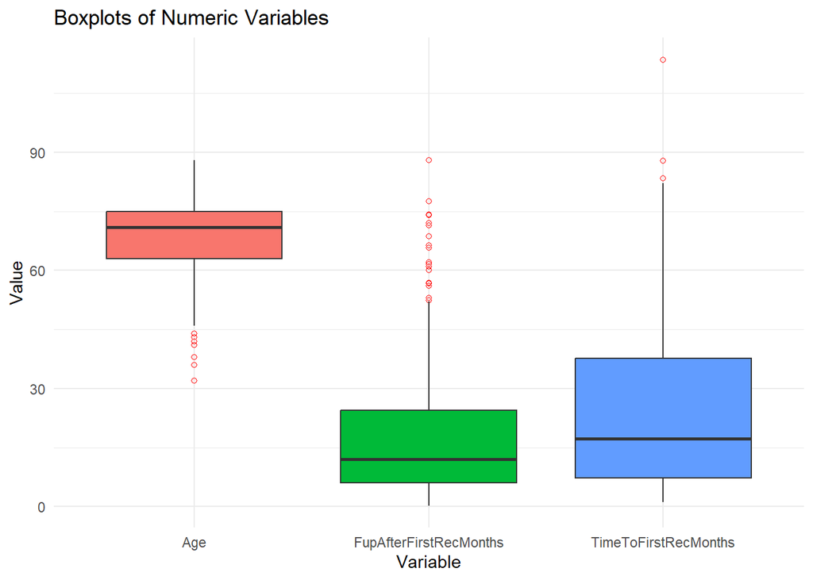

```r
# Reshape the dataset to long format
df_long <- df %>%
  pivot_longer(cols = c(Age, TimeToFirstRecMonths, FupAfterFirstRecMonths),
               names_to = "Variable",
               values_to = "Value")

# Create a single boxplot with facets for each variable
ggplot(df_long, aes(x = Variable, y = Value, fill = Variable)) +
  geom_boxplot(outlier.colour = "red", outlier.shape = 1) +
  labs(title = "Boxplots of Numeric Variables",
       x = "Variable",
       y = "Value") +
  theme_minimal() +
  theme(legend.position = "none")
```

### Age

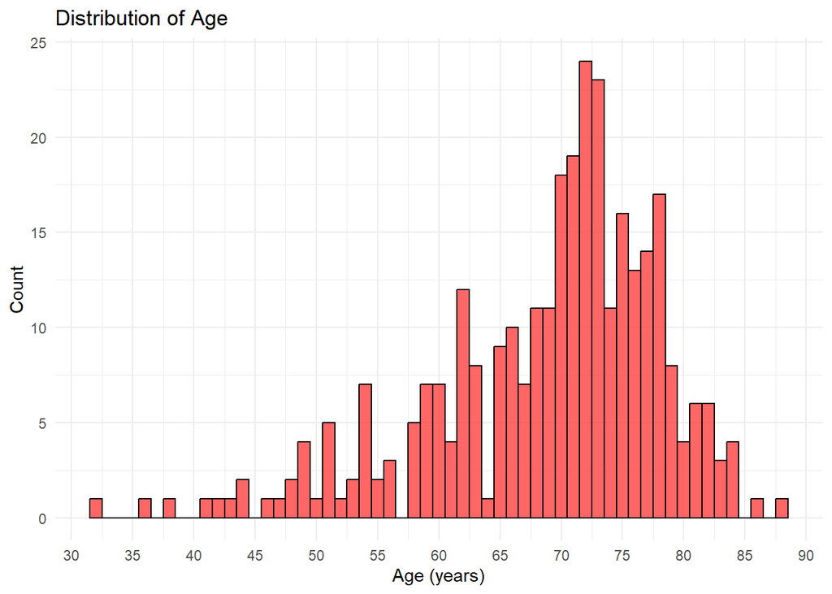

```r
ggplot(df, aes(x = Age)) +
  geom_histogram(binwidth = 1, fill = "brown1", color = "black", alpha = 0.8) +
  labs(title = "Distribution of Age",
       x = "Age (years)",
       y = "Count") +
  theme_minimal() +
  scale_x_continuous(breaks = seq(30, 90, by = 5))  # Set x-axis breaks at every 5 years
```

### FupAfterFirstRecMonths

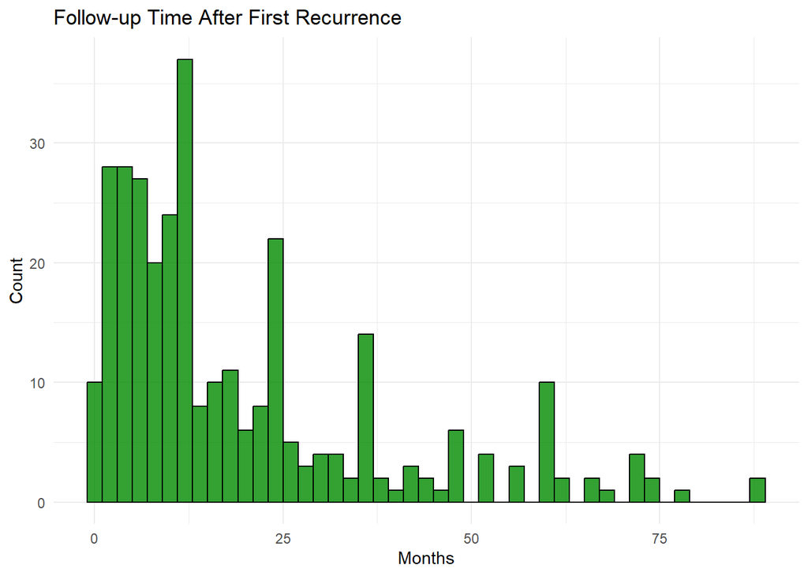

```r
ggplot(df, aes(x = FupAfterFirstRecMonths)) +
  geom_histogram(binwidth = 2, fill = "green4", color = "black", alpha = 0.8) +
  labs(title = "Follow-up Time After First Recurrence",
       x = "Months",
       y = "Count") +
  theme_minimal()
```

### TimeToFirstRecMonths

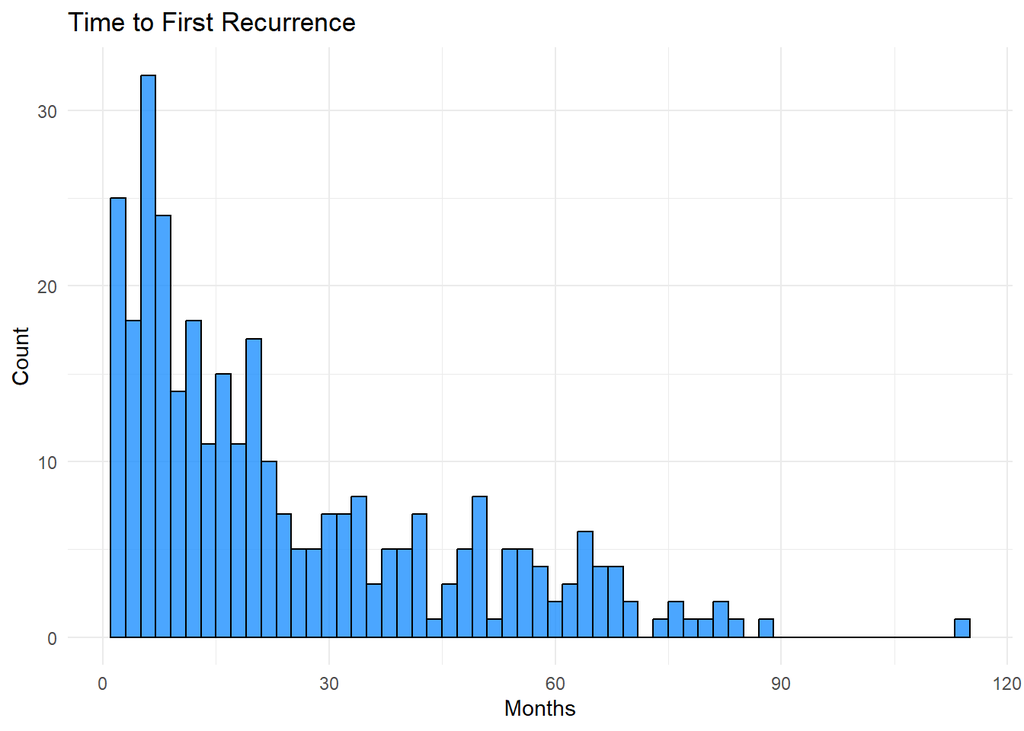

```r
ggplot(df, aes(x = TimeToFirstRecMonths)) +
  geom_histogram(binwidth = 2, fill = "dodgerblue", color = "black", alpha = 0.8) +
  labs(title = "Time to First Recurrence",
       x = "Months",
       y = "Count") +
  theme_minimal()
```

# 2. Nonparametric analysis of the association between treatment (RecTreat) and each of the two competingevents (second recurrence, death without second recurrence)

```r
# Compute Cumulative Incidence Functions
cif <- with(df, cuminc(
  ftime = FupAfterFirstRecMonths,
  fstatus = SecondRecOrDeath,
  group = RecTreat))

print(cif)
```

```
## Tests:
##         stat          pv df
## 1 10.2843151 0.001341658  1
## 2  0.2227961 0.636917640  1
## Estimates and Variances:
## $est
##               20        40        60        80
## CUR 1 0.17431674 0.3172042 0.4058188 0.4058188
## PAL 1 0.40266812 0.5301606 0.5481821        NA
## CUR 2 0.09504052 0.1131305 0.1131305 0.2734808
## PAL 2 0.10873425 0.1274320 0.1490578        NA
##
## $var
##                 20           40          60          80
## CUR 1 0.0017506496 0.0034306841 0.004997505 0.004997505
## PAL 1 0.0016210114 0.0021622366 0.002311771          NA
## CUR 2 0.0010727601 0.0013583115 0.001358311 0.027133722
## PAL 2 0.0006346644 0.0007835335 0.001217884          NA
```

A competing risks analysis was performed to assess the effect of treatment of the first recurrence —**curative (CUR)** versus **palliative (PAL)** — on two mutually exclusive outcomes following the first recurrence of hepatocellular carcinoma (HCC).

The results were obtained from a competing risks analysis ( using *cuminc()* from the *cmprsk* package), and these values correspond to:

1. Gray’s test for differences between treatment groups for each type of event.
2. Cumulative incidence estimates (Aalen-Johansen estimator).
3. Variance estimates for those cumulative incidences.

### (a) Gray’s Test Results

Gray’s test revealed a statistically significant difference in the cumulative incidence of second recurrence (p = 0.001), with curative treatment (CUR) associated with a markedly lower risk compared to palliative treatment (PAL). In contrast, the difference in cumulative incidence of death without second recurrence between treatment groups was not statistically significant (p = 0.637), suggesting that treatment type had no significant effect on mortality risk in the absence of recurrence.

### (b) Cumulative incidence estimates (Aalen-Johansen estimator)

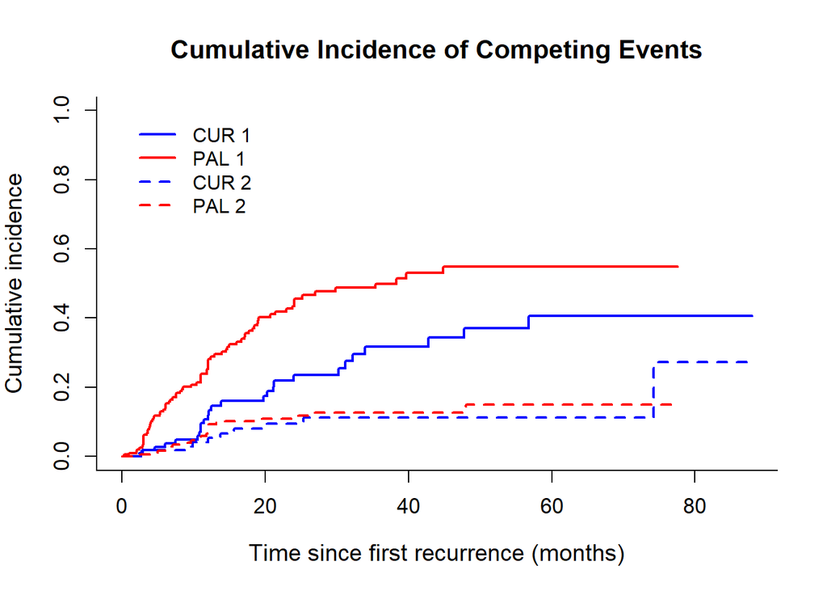

```r
# Aalen-Johansen CIF plot
plot(cif,
     lty = c(1, 1, 2, 2),
     col = c("blue", "red", "blue", "red"),
     lwd = 2,
     xlab = "Time since first recurrence (months)",
     ylab = "Cumulative incidence",
     main = "Cumulative Incidence of Competing Events",
     xaxs = "r", yaxs = "r",
     cex.lab = 1.2, cex.main = 1.3, cex.axis = 1.1)
```

### (c) Variance estimates

The variance estimates provide a measure of precision for the cumulative incidence values:

At later time points (e.g., 80 months), variance increases substantially (e.g., 0.027 for CUR death), signaling reduced precision as fewer patients remain under observation.

## Conclusions

These findings support the following conclusions:

- Curative treatment (CUR) is associated with a significantly lower incidence of second recurrence compared to palliative treatment.
- No significant difference in the risk of death without recurrence was observed between groups.
- Estimates at longer follow-up times (>60 months) should be interpreted with caution due to increasing variance and reduced sample size, especially in the PAL group.

# 3. Univariate analysis (Cox model) of the association of each independent variable with each of the two competing events (second recurrence, death without second recurrence) and with the composite endpoint (second recurrence or death)

### Modeling Strategy

In the univariate analysis, certain variables from the dataset *idpat*, *FupAfterFirstRecMonths*, and *SecondRecOrDeath* — were intentionally excluded as independent predictors. These variables serve structural or outcome - related roles in the analysis:

- *idpat* is a patient identifier and carries no clinical relevance as a predictor.
- *FupAfterFirstRecMonths* is the time-to-event variable used in the survival function and is not a covariate.
- *SecondRecOrDeath* defines the event status and is the primary outcome variable in the survival models.

Including these variables as predictors would be methodologically inappropriate and could bias or invalidate the model interpretation. All other clinically relevant and available covariates were included in the univariate analyses.

```r
# Define variables to analyze
vars <- c("Age", "Gender", "RecMultinodular", "RecNoduleLargeSize",
          "RecExtrahepatic", "TimeToFirstRecMonths", "RecTreat")

# Outcome variables for cause-specific Cox models
# Composite endpoint (event = 1 or 2)
df$composite_event <- ifelse(df$SecondRecOrDeath != 0, 1, 0)

# Second recurrence as event, others as censored
df$cs_rec <- ifelse(df$SecondRecOrDeath == 1, 1, 0)

# Death without recurrence as event, others as censored
df$cs_death <- ifelse(df$SecondRecOrDeath == 2, 1, 0)

run_univ_cox <- function(time, event, data, vars, outcome_label) {

  cat(paste("Univariate Cox Model for:", outcome_label, "\n"))

  # Loop through each variable
  for (v in vars) {
    # Create the formula for the Cox model
    formula <- as.formula(paste0("Surv(", time, ", ", event, ") ~ ", v))

    # Fit the Cox model
    model <- coxph(formula, data = data)

    # Get the summary
    model_summary <- summary(model)
    print(model_summary)
  }
}
```

### Results: Second Recurrence

```r
run_univ_cox("FupAfterFirstRecMonths", "cs_rec", df, vars, "Second Recurrence")
```

```
## Univariate Cox Model for: Second Recurrence
## Call:
## coxph(formula = formula, data = data)
##
##   n= 317, number of events= 103
##
##        coef exp(coef) se(coef)     z Pr(>|z|)
## Age 0.01655   1.01668  0.01174 1.409    0.159
##
##     exp(coef) exp(-coef) lower .95 upper .95
## Age     1.017     0.9836    0.9936      1.04
##
## Concordance= 0.528  (se = 0.031 )
## Likelihood ratio test= 2.09  on 1 df,   p=0.1
## Wald test            = 1.99  on 1 df,   p=0.2
## Score (logrank) test = 1.99  on 1 df,   p=0.2
##
## Call:
## coxph(formula = formula, data = data)
##
##   n= 317, number of events= 103
##
##           coef exp(coef) se(coef)     z Pr(>|z|)
## GenderM 0.3733    1.4525   0.2493 1.497    0.134
##
##         exp(coef) exp(-coef) lower .95 upper .95
## GenderM     1.453     0.6884     0.891     2.368
##
## Concordance= 0.529  (se = 0.022 )
## Likelihood ratio test= 2.41  on 1 df,   p=0.1
## Wald test            = 2.24  on 1 df,   p=0.1
## Score (logrank) test = 2.27  on 1 df,   p=0.1
##
## Call:
## coxph(formula = formula, data = data)
##
##   n= 317, number of events= 103
##
##                   coef exp(coef) se(coef)     z Pr(>|z|)
## RecMultinodular 0.7435    2.1033   0.2105 3.532 0.000413 ***
```

[output cut: 65 more lines]

```
##
##   n= 317, number of events= 103
##
##               coef exp(coef) se(coef)    z Pr(>|z|)
## RecTreatPAL 0.7552    2.1281   0.2275 3.32 0.000901 ***
## ---
## Signif. codes:  0 '***' 0.001 '**' 0.01 '*' 0.05 '.' 0.1 ' ' 1
##
##             exp(coef) exp(-coef) lower .95 upper .95
## RecTreatPAL     2.128     0.4699     1.363     3.324
##
## Concordance= 0.599  (se = 0.022 )
## Likelihood ratio test= 12.26  on 1 df,   p=5e-04
## Wald test            = 11.02  on 1 df,   p=9e-04
## Score (logrank) test = 11.54  on 1 df,   p=7e-04
```

In the univariate Cox analysis for risk of second recurrence, three variables showed a statistically significant association. Multinodular recurrence (*RecMultinodular*, HR: 2.10, 95% CI: 1.39–3.18, p < 0.001) and palliative treatment at recurrence (*RecTreat*, HR: 2.13, 95% CI: 1.36–3.32, p < 0.001) were both strongly associated with more than double the risk of a second recurrence. Additionally, large size of recurrent nodules (*RecNoduleLargeSize*, HR: 1.78, 95% CI: 1.08–2.93, p = 0.024) was significantly linked with increased risk, although with a more moderate effect size

A shorter time to first recurrence (*TimeToFirstRecMonths*) was also significantly associated with increased risk of second recurrence, with a hazard ratio less than 1 (HR: 0.976, 95% CI: 0.963–0.989, p < 0.001), indicating that a longer interval before first recurrence is protective.

Other variables including *Age* (HR: 1.02, p = 0.159), *Gender* (HR: 1.45, p = 0.134), and presence of extrahepatic recurrence (*RecExtrahepatic*, HR: 1.26, p = 0.353) did not reach statistical significance in this univariate model, suggesting weaker or non-significant individual associations with second recurrence.

Concordance indices ranged from 0.53 to 0.62, indicating moderate predictive power, highest for TimeToFirstRecMonths (0.62). Likelihood ratio, Wald, and Score tests consistently confirmed strong significance for *RecMultinodular*, *RecTreat*, and *TimeToFirstRecMonths* (p < 0.001), while *Age*, *Gender*, and *RecExtrahepatic* showed no significant effects (p > 0.1). This supports these key variables as reliable predictors of second recurrence risk.

### Results: Death Without Second Recurrence

```r
run_univ_cox("FupAfterFirstRecMonths", "cs_death", df, vars, "Death without Second Recurrence")
```

```
## Univariate Cox Model for: Death without Second Recurrence
## Call:
## coxph(formula = formula, data = data)
##
##   n= 317, number of events= 30
##
##         coef exp(coef) se(coef)    z Pr(>|z|)
## Age 0.006714  1.006736 0.020964 0.32    0.749
##
##     exp(coef) exp(-coef) lower .95 upper .95
## Age     1.007     0.9933    0.9662     1.049
##
## Concordance= 0.511  (se = 0.06 )
## Likelihood ratio test= 0.1  on 1 df,   p=0.7
## Wald test            = 0.1  on 1 df,   p=0.7
## Score (logrank) test = 0.1  on 1 df,   p=0.7
##
## Call:
## coxph(formula = formula, data = data)
##
##   n= 317, number of events= 30
##
##            coef exp(coef) se(coef)      z Pr(>|z|)
## GenderM -0.2220    0.8009   0.3986 -0.557    0.578
##
##         exp(coef) exp(-coef) lower .95 upper .95
## GenderM    0.8009      1.249    0.3666     1.749
##
## Concordance= 0.559  (se = 0.05 )
## Likelihood ratio test= 0.3  on 1 df,   p=0.6
## Wald test            = 0.31  on 1 df,   p=0.6
## Score (logrank) test = 0.31  on 1 df,   p=0.6
##
## Call:
## coxph(formula = formula, data = data)
##
##   n= 317, number of events= 30
##
##                   coef exp(coef) se(coef)     z Pr(>|z|)
## RecMultinodular 0.4182    1.5192   0.3740 1.118    0.264
```

[output cut: 59 more lines]

```
## Call:
## coxph(formula = formula, data = data)
##
##   n= 317, number of events= 30
##
##               coef exp(coef) se(coef)     z Pr(>|z|)
## RecTreatPAL 0.4058    1.5005   0.3915 1.036      0.3
##
##             exp(coef) exp(-coef) lower .95 upper .95
## RecTreatPAL       1.5     0.6664    0.6966     3.232
##
## Concordance= 0.548  (se = 0.047 )
## Likelihood ratio test= 1.12  on 1 df,   p=0.3
## Wald test            = 1.07  on 1 df,   p=0.3
## Score (logrank) test = 1.09  on 1 df,   p=0.3
```

In the univariate Cox analysis for death without second recurrence, only one variable showed a statistically significant association: patients with large recurrent nodules (*RecNoduleLargeSize*) had a significantly increased risk (HR: 2.46, 95% CI: 1.05–5.77, p = 0.039). This was supported by a Wald test statistic of 4.27 (p = 0.04), a Score (logrank) test of 4.57 (p = 0.03), and a Likelihood ratio test of 3.62 (p = 0.06), all indicating statistical evidence for its prognostic value.

Other variables showed no statistically significant association with death without second recurrence, as indicated by non-significant hazard ratios and uniformly high p-values across all tests. *Age* (HR = 1.01, 95% CI: 0.97–1.05) had a likelihood ratio, Wald, and Score test p = 0.7. *Gender* (HR = 0.80, 95% CI: 0.37–1.75) yielded p-values around 0.6 across all tests. Similarly, *RecMultinodular* (HR = 1.52, 95% CI: 0.73–3.16), *RecExtrahepatic* (HR = 1.60, 95% CI: 0.68–3.76), and *RecTreatPAL* (HR = 1.50, 95% CI: 0.70–3.23) all had test p-values near 0.3. *TimeToFirstRecMonths* (HR = 1.00, 95% CI: 0.98–1.02) showed no association, with all three tests yielding p = 1.0.

Concordance indices ranged from 0.458 to 0.575, indicating limited predictive discrimination, with the highest concordance observed for RecNoduleLargeSize. Overall, this suggests that among the clinical variables evaluated, only the presence of large recurrent nodules may serve as an independent predictor of mortality prior to a second recurrence.

### Composite endpoint (second recurrence or death)

```r
run_univ_cox("FupAfterFirstRecMonths", "composite_event", df, vars, "Composite Endpoint (Recurrence or Death)")
```

```
## Univariate Cox Model for: Composite Endpoint (Recurrence or Death)
## Call:
## coxph(formula = formula, data = data)
##
##   n= 317, number of events= 133
##
##        coef exp(coef) se(coef)     z Pr(>|z|)
## Age 0.01427   1.01437  0.01024 1.393    0.164
##
##     exp(coef) exp(-coef) lower .95 upper .95
## Age     1.014     0.9858    0.9942     1.035
##
## Concordance= 0.524  (se = 0.027 )
## Likelihood ratio test= 2.02  on 1 df,   p=0.2
## Wald test            = 1.94  on 1 df,   p=0.2
## Score (logrank) test = 1.94  on 1 df,   p=0.2
##
## Call:
## coxph(formula = formula, data = data)
##
##   n= 317, number of events= 133
##
##           coef exp(coef) se(coef)    z Pr(>|z|)
## GenderM 0.2227    1.2495   0.2102 1.06    0.289
##
##         exp(coef) exp(-coef) lower .95 upper .95
## GenderM     1.249     0.8003    0.8276     1.886
##
## Concordance= 0.509  (se = 0.021 )
## Likelihood ratio test= 1.17  on 1 df,   p=0.3
## Wald test            = 1.12  on 1 df,   p=0.3
## Score (logrank) test = 1.13  on 1 df,   p=0.3
##
## Call:
## coxph(formula = formula, data = data)
##
##   n= 317, number of events= 133
##
##                   coef exp(coef) se(coef)     z Pr(>|z|)
## RecMultinodular 0.6683    1.9509   0.1831 3.649 0.000263 ***
```

[output cut: 65 more lines]

```
##
##   n= 317, number of events= 133
##
##               coef exp(coef) se(coef)     z Pr(>|z|)
## RecTreatPAL 0.6722    1.9586   0.1961 3.428 0.000609 ***
## ---
## Signif. codes:  0 '***' 0.001 '**' 0.01 '*' 0.05 '.' 0.1 ' ' 1
##
##             exp(coef) exp(-coef) lower .95 upper .95
## RecTreatPAL     1.959     0.5106     1.334     2.877
##
## Concordance= 0.588  (se = 0.02 )
## Likelihood ratio test= 12.83  on 1 df,   p=3e-04
## Wald test            = 11.75  on 1 df,   p=6e-04
## Score (logrank) test = 12.19  on 1 df,   p=5e-04
```

In the univariate Cox analysis of the composite endpoint (recurrence or death), several variables were significantly associated with increased risk. Multinodular recurrence (*RecMultinodular*, HR: 1.95, 95% CI: 1.36–2.79), large recurrent nodules (*RecNoduleLargeSize*, HR: 1.92, 95% CI: 1.25–2.96), and palliative treatment at recurrence (*RecTreatPAL*, HR: 1.96, 95% CI: 1.33–2.88) all showed strong associations, with p-values < 0.005 across likelihood ratio, Wald, and Score (logrank) tests. These findings suggest that recurrence pattern and treatment type may be critical prognostic indicators.

Time to first recurrence (TimeToFirstRecMonths) was inversely associated with risk (HR: 0.98, 95% CI: 0.97–0.99), with highly significant test results (p ≤ 0.001), indicating that longer recurrence-free intervals may be protective.

In contrast, other variables showed no statistically significant association. *Age* (HR: 1.01, 95% CI: 0.99–1.04) had p = 0.2 across all tests; *Gender* (HR: 1.25, 95% CI: 0.83–1.89) and *RecExtrahepatic* (HR: 1.34, 95% CI: 0.87–2.04) both had p-values in the 0.2–0.3 range, suggesting no evidence of prognostic relevance.

Concordance indices ranged from 0.509 to 0.588, indicating modest predictive performance, with the highest values observed for *TimeToFirstRecMonths* and *RecTreatPAL.* These findings suggest that recurrence pattern, treatment type, and timing are important factors in predicting adverse clinical progression.

# 4. Developing the predictive model (Cox model) for the composite endpoint with all covariates

```r
# The formula with all predictors
full_formula <- as.formula("Surv(FupAfterFirstRecMonths, composite_event) ~
                            Age + Gender + RecMultinodular + RecNoduleLargeSize +
                            RecExtrahepatic + TimeToFirstRecMonths + RecTreat")

# Fit the multivariable Cox model
cox_model <- coxph(full_formula, data = df)

# Summary of the model
summary(cox_model)
```

```
## Call:
## coxph(formula = full_formula, data = df)
##
##   n= 317, number of events= 133
##
##                           coef exp(coef)  se(coef)      z Pr(>|z|)
## Age                   0.015871  1.015998  0.010826  1.466 0.142625
## GenderM               0.309043  1.362121  0.214739  1.439 0.150106
## RecMultinodular       0.465020  1.592047  0.199432  2.332 0.019715 *
## RecNoduleLargeSize    0.618714  1.856539  0.230024  2.690 0.007150 **
## RecExtrahepatic       0.204896  1.227398  0.222137  0.922 0.356326
## TimeToFirstRecMonths -0.018170  0.981994  0.005381 -3.377 0.000733 ***
## RecTreatPAL           0.447803  1.564870  0.216789  2.066 0.038865 *
## ---
## Signif. codes:  0 '***' 0.001 '**' 0.01 '*' 0.05 '.' 0.1 ' ' 1
##
##                      exp(coef) exp(-coef) lower .95 upper .95
## Age                      1.016     0.9843    0.9947    1.0378
## GenderM                  1.362     0.7341    0.8942    2.0749
## RecMultinodular          1.592     0.6281    1.0770    2.3535
## RecNoduleLargeSize       1.857     0.5386    1.1828    2.9141
## RecExtrahepatic          1.227     0.8147    0.7941    1.8970
## TimeToFirstRecMonths     0.982     1.0183    0.9717    0.9924
## RecTreatPAL              1.565     0.6390    1.0232    2.3934
##
## Concordance= 0.67  (se = 0.026 )
## Likelihood ratio test= 43.15  on 7 df,   p=3e-07
## Wald test            = 40.98  on 7 df,   p=8e-07
## Score (logrank) test = 42.34  on 7 df,   p=4e-07
```

A multivariable Cox proportional hazards model was developed to identify independent prognostic factors associated with the composite endpoint of second recurrence or death. The model demonstrated adequate overall fit, with a concordance index of 0.67, indicating modest discriminative ability, consistent with typical values reported for clinical prediction models based on standard clinicopathologic features. Global model significance was confirmed by highly significant results in the likelihood ratio, Wald, and Score tests (all p < 0.001), supporting the joint contribution of included covariates.

Four variables retained statistical significance in the adjusted model. Multinodular recurrence (*RecMultinodular*) was associated with a 59% increased hazard (HR = 1.59, 95% CI: 1.08–2.35, p = 0.020), while the presence of large recurrent nodules (*RecNoduleLargeSize*) conferred an 86% higher risk (HR = 1.86, 95% CI: 1.18–2.91, p = 0.007). Patients receiving palliative treatment at first recurrence (*RecTreatPAL*) had a 56% greater hazard compared to those treated curatively (HR = 1.56, 95% CI: 1.02–2.39, p = 0.039).

Additionally, *TimeToFirstRecMonths* was independently protective: each additional month between surgery and recurrence was associated with a 2% reduction in hazard (HR = 0.98, 95% CI: 0.97–0.99, p < 0.001), suggesting that early recurrence reflects more aggressive disease biology.

In contrast, *Age* (HR = 1.02, 95% CI: 0.99–1.04, p = 0.143), *Gender* (HR = 1.36 for males, 95% CI: 0.89–2.07, p = 0.150), and extrahepatic recurrence (*RecExtrahepatic*, HR = 1.23, 95% CI: 0.79–1.90, p = 0.356), were not significantly associated with the composite endpoint in the multivariable analysis.

These findings indicate that tumor burden at recurrence (nodularity and size), treatment intent, and the timing of recurrence are key factors associated with disease progression or death. The results support incorporating these variables into clinical decision-making and risk stratification models.

# 5. Evaluate functional form of continuous variables and “Proportional Hazards” assumption for all covariates

To evaluate the appropriateness of the linear specification for continuous covariates, Martingale residuals from the multivariable Cox model were plotted against *Age* and *TimeToFirstRecMonths.*

```r
# Martingale residuals for functional form
resid_martingale <- residuals(cox_model, type = "martingale")


plot_martingale <- function(varname) {
  # Extract variable values
  x_var <- df[[varname]]

  # Plot Martingale residuals
  plot(x_var, resid_martingale,
       xlab = varname, ylab = "Martingale Residuals",
       main = paste("Check functional form of", varname))
  lines(lowess(x_var, resid_martingale), col = "red")
}
```

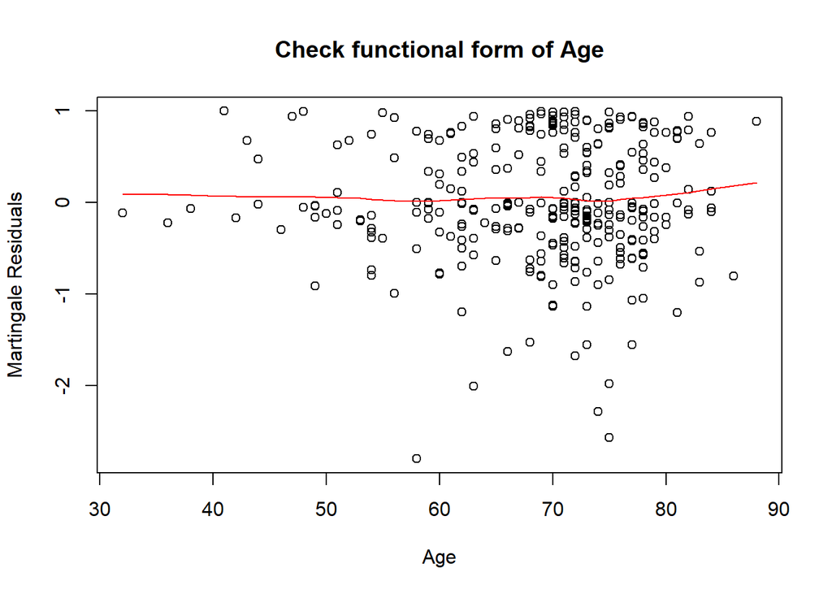

```r
plot_martingale('Age')
```

The residual plot for Age showed no evidence of systematic deviation or curvature, indicating that a linear functional form is suitable for modeling this variable.

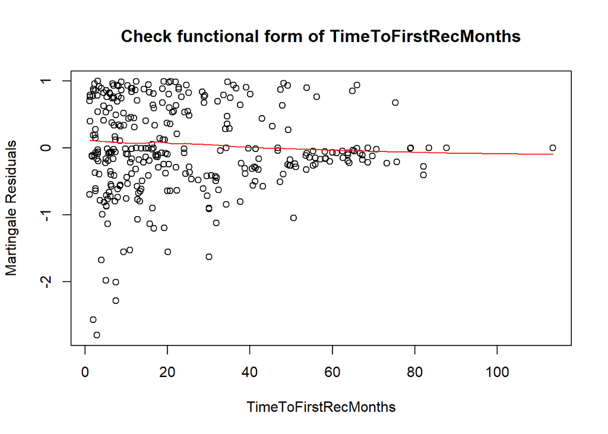

```r
plot_martingale('TimeToFirstRecMonths')
```

Similarly, the plot for *TimeToFirstRecMonths* revealed no discernible nonlinearity. While some variability was observed at lower time values (<20 months), the overall trend of the residual smoother remained approximately linear, suggesting that a transformation is not required.

```r
# Test PH assumption
ph_test <- cox.zph(cox_model)
print(ph_test)
```

```
##                      chisq df     p
## Age                  0.701  1 0.403
## Gender               2.008  1 0.157
## RecMultinodular      0.246  1 0.620
## RecNoduleLargeSize   0.837  1 0.360
## RecExtrahepatic      0.507  1 0.477
## TimeToFirstRecMonths 0.127  1 0.722
## RecTreat             2.740  1 0.098
## GLOBAL               8.628  7 0.280
```

The proportional hazards (PH) assumption was tested using Schoenfeld residuals. No statistically significant violations were detected for any of the covariates (all p > 0.05). The global test for the model also indicated no departure from the PH assumption (χ² = 8.63, df = 7, p = 0.280).

Notably, the test for *RecTreat* approached significance (χ² = 2.74, p = 0.098), which may warrant closer attention in sensitivity analyses, but does not constitute formal evidence of non-proportionality.

Overall, the assumptions of linearity and proportional hazards were adequately met, supporting the validity of the Cox model specification.

# 6. Evaluate model performance (calibration, discrimination, Net Benefit) for prediction of event risk at a fixed time-point (e.g., 36 months)

```r
# Define the fixed time point t = 36 months
t <- 36

# Create a binary event variable: did the event happen by t = 36 months?
df$event_t <- with(df, ifelse(FupAfterFirstRecMonths <= t & composite_event == 1, 1, 0))

# Predict survival probability
surv_fit <- survfit(cox_model, newdata = df)

# Extract survival
surv_probs <- as.vector(summary(surv_fit, times = t)$surv)
df$risk_pred <- 1 - surv_probs
```

### Calibration

Calibration assesses the agreement between predicted and observed event risks. We stratified the cohort into deciles based on predicted 36-month risk and compared mean predicted risk with observed event rates within each decile.

```r
# Compute decile cut-points on the predicted risk
breaks <- quantile(df$risk_pred, probs = seq(0, 1, 0.1), na.rm = TRUE)

# Assign each observation to a decile (1-10)
df$risk_decile <- cut(df$risk_pred,
                      breaks = breaks,
                      include.lowest = TRUE,
                      labels = 1:10)

# Aggregate with a simple mean
cal_data <- aggregate(cbind(risk_pred, event_t) ~ risk_decile,
                      data = df,
                      FUN  = mean,
                      na.rm = TRUE)

# Rename columns for clarity
names(cal_data) <- c("risk_decile", "mean_pred", "obs_event")

# Define new column cal_error (calibration error)
cal_data$cal_error <- cal_data$obs_event - cal_data$mean_pred

# Print the result
print(cal_data)
```

```
##    risk_decile mean_pred obs_event   cal_error
## 1            1 0.2115553 0.0937500 -0.11780532
## 2            2 0.3316638 0.1875000 -0.14416379
## 3            3 0.3879218 0.2580645 -0.12985730
## 4            4 0.4373715 0.2500000 -0.18737146
## 5            5 0.4908662 0.3125000 -0.17836619
## 6            6 0.5527598 0.5161290 -0.03663079
## 7            7 0.6221676 0.5312500 -0.09091758
## 8            8 0.6919266 0.6451613 -0.04676527
## 9            9 0.7659206 0.5937500 -0.17217061
## 10          10 0.8766942 0.5625000 -0.31419420
```

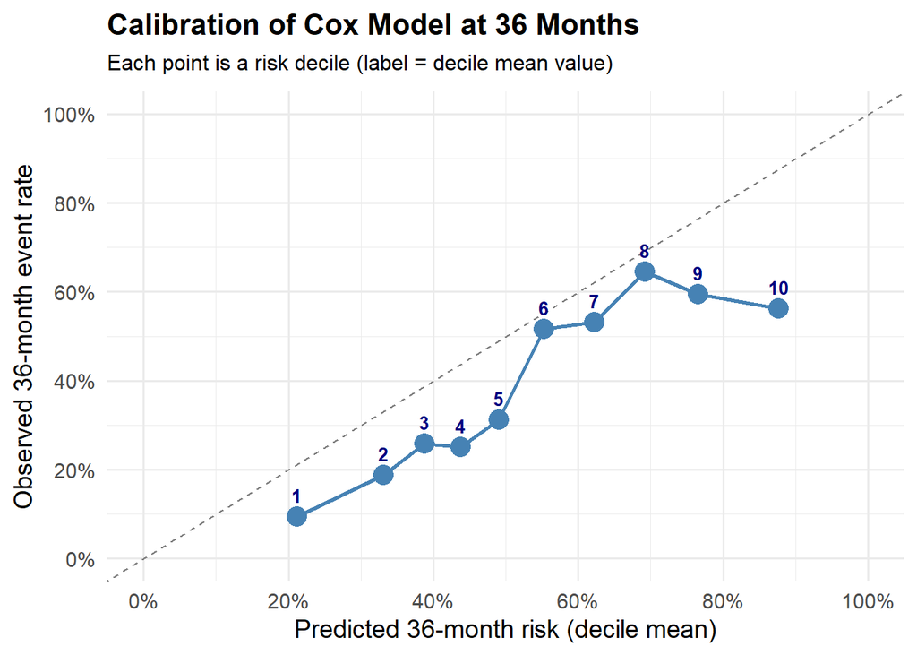

```r
# Plot calibration
ggplot(cal_data, aes(x = mean_pred, y = obs_event)) +
  # 45° reference line
  geom_abline(slope = 1, intercept = 0, linetype = "dashed", color = "gray50") +
  # connecting line
  geom_line(color = "steelblue", size = 1) +
  # points
  geom_point(color = "steelblue", size = 5) +
  # decile labels
  geom_text(aes(label = risk_decile),
            color = "navy",
            vjust = -1,
            fontface = "bold",
            size = 3.5) +
  # percent scales
  scale_x_continuous(limits = c(0,1), breaks = seq(0,1,0.2), labels = percent) +
  scale_y_continuous(limits = c(0,1), breaks = seq(0,1,0.2), labels = percent) +
  labs(
    x = "Predicted 36-month risk (decile mean)",
    y = "Observed 36-month event rate",
    title = "Calibration of Cox Model at 36 Months",
    subtitle = "Each point is a risk decile (label = decile mean value)"
  ) +
  theme_minimal(base_size = 14) +
  theme(
    plot.title = element_text(face = "bold", size = 16),
    plot.subtitle = element_text(size = 12, margin = margin(b = 10))
  )
```

## Discrimination

```r
# Compute ROC for the model
roc1 <- roc(df$event_t, df$risk_pred)

#  Plot ROC curve
plot(1 - roc1$specificities, roc1$sensitivities,
     type = 'l', lwd = 3,
     title = 'ROC Curve',
     xlab = 'False Positive Rate (1 – Specificity)',
     ylab = 'True Positive Rate (Sensitivity)',
     xaxt = 'n', yaxt = 'n',
     xlim = c(0,1), ylim = c(0,1),
     cex.lab = 1.5, frame = FALSE)

axis(1, at = seq(0,1,0.25), pos = 0, cex.axis = 1.3)
axis(2, at = seq(0,1,0.25), pos = 0, cex.axis = 1.3)

# Chance line:
abline(a=0, b=1, lty = 2, lwd = 2)
lines(c(0,1), c(1,1), lty = 1)
lines(c(1,1), c(0,1), lty = 1)

#  Youden index & optimal cutoff for the model
Youden <- roc1$sensitivities + roc1$specificities - 1
opt <- roc1$thresholds[which.max(Youden)]
cbind(optimal.cut.off1 = opt, Youden = max(Youden))
```

```
##      optimal.cut.off1    Youden
## [1,]        0.5331605 0.3967083
```

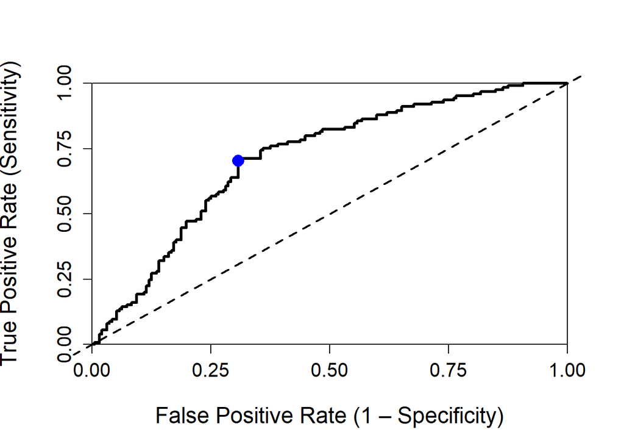

```r
# Mark it on the curve
points(
  1 - roc1$specificities[roc1$thresholds == opt],
  roc1$sensitivities[roc1$thresholds == opt],
  pch = 16, cex = 1.8, col = 'blue'
)
```

```r
# Calculate and print AUC with 95% Confidence Interval
auc_val <- roc1$auc
auc_ci <- ci.auc(roc1)

cat(sprintf("AUC = %.4f (95%% CI: %.4f - %.4f)\n", auc_val, auc_ci[1], auc_ci[3]))
```

```
## AUC = 0.7146 (95% CI: 0.6577 - 0.7714)
```

The model’s discrimination ability was evaluated using the Area Under the Receiver Operating Characteristic Curve (AUC). The estimated AUC of 0.715 (95% Confidence Interval [CI]: 0.658 to 0.771) indicates moderate discriminatory performance. This means that, when randomly selecting one patient who experienced the event by 36 months and one who did not, the model correctly assigns a higher predicted risk to the former approximately 71.5% of the time.

The confidence interval excludes 0.5, confirming that the model’s discrimination is significantly better than chance. The ROC curve further demonstrates this, showing clear separation above the diagonal no-skill reference line.

# Net Benefit

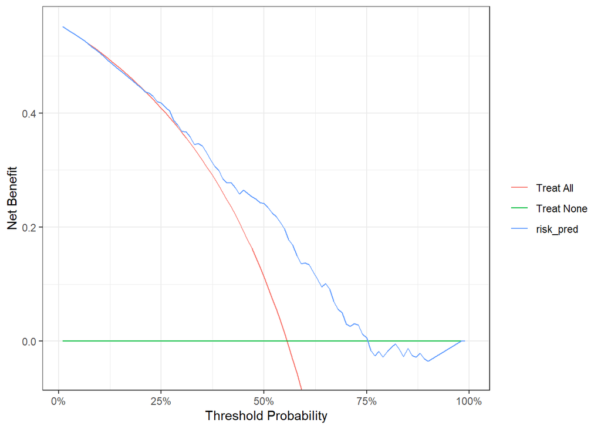

```r
# Decision Curve Analysis

df$time_t <- pmin(df$FupAfterFirstRecMonths, t)


# Run DCA on the two risk predictors
dca_t <- dca(
  formula    = Surv(time_t, event_t) ~ risk_pred,
  data       = df,
  time       = t,
  thresholds = seq(0.01, 1, 0.01)
)

# Plot net benefit curves
plot(
  dca_t,
  type             = "net_benefit",
  smooth           = FALSE,
  show_ggplot_code = FALSE,
  xlab             = "Risk Threshold",
  ylab             = "Net Benefit",
  main             = "Decision Curve Analysis at 36 Months"
)
```

# 7. Prediction of event risk at a fixed time-point (e.g., 36 months) for 3 “type” subjects (randomly selected in the dataset or new hypothetical subjects) based on the model.

```r
# For reproducibility
set.seed(7)

# Randomly pick three row indices
idx <- sample(seq_len(nrow(df)), size = 3)

# Subset those patients
df_three <- df[idx, ]
print(df_three)
```

```
##     idpat Age Gender RecMultinodular RecNoduleLargeSize RecExtrahepatic
## 298   298  54      M               0                  0               1
## 103   103  76      M               1                  0               1
## 194   194  76      F               1                  0               0
##     TimeToFirstRecMonths FupAfterFirstRecMonths SecondRecOrDeath RecTreat
## 298            13.278689              41.654749                0      PAL
## 103             6.786885               3.945201                0      PAL
## 194             4.491803              13.939711                1      PAL
##     composite_event cs_rec cs_death event_t risk_pred risk_decile    time_t
## 298               0      0        0       0 0.5316118           6 36.000000
## 103               0      0        0       0 0.8543346          10  3.945201
## 194               1      1        0       1 0.6992093           8 13.939711
```

```r
# Compute linear predictors only for those 3 subjects (LP = β^T X)
df_three$lp <- predict(cox_model, newdata = df_three, type = "lp")

# Extract baseline cumulative hazard H0(t) at t = 36 months
bh <- basehaz(cox_model, centered = FALSE)
H0_36_three <- bh$hazard[ which.min(abs(bh$time - 36)) ]
```

The survival probability at 36 months for a subject $i$ is estimated using:

$$S_i(t) = \exp \big( -H_0(t) \cdot
\exp(\text{LP}_i) \big)$$

where:

- $H_0(t)$ is the baseline cumulative hazard at 36 months
- $\text{LP}_i = \beta^T X_i$ s the linear predictor for subject $i$

```r
# Compute individual survival at 36 months
S36_three <- exp(-H0_36_three * exp(df_three$lp))
risk36_three <- 1 - S36_three

# Combine into a results table
results_three <- cbind(
  df_three[, "idpat"],
  linear_predictor = round(df_three$lp, 3),
  surv36           = round(S36_three, 3),
  risk36           = round(risk36_three, 3)
)

print(results_three, method = "render")
```

```
##          linear_predictor surv36 risk36
## [1,] 298            0.931  0.672  0.328
## [2,] 103            1.863  0.364  0.636
## [3,] 194            1.391  0.533  0.467
```

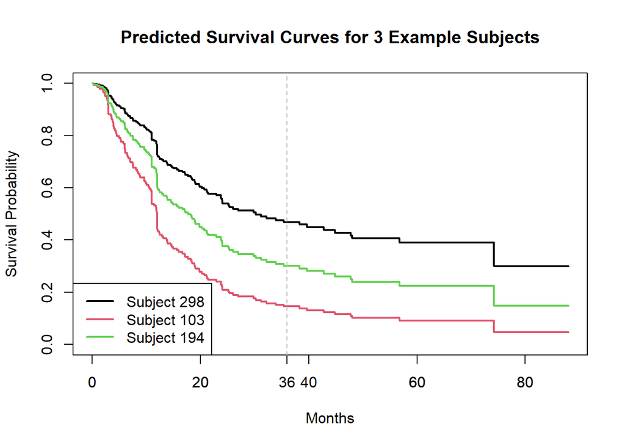

```r
# Individual survival curves
newdata <- df_three
fit_indiv <- survfit(cox_model, newdata = newdata)

plot(fit_indiv, col = 1:3, lwd = 2,
     xlab = "Months", ylab = "Survival Probability",
     main = "Predicted Survival Curves for 3 Example Subjects")
legend("bottomleft", legend = paste("Subject", newdata$idpat),
       col = 1:3, lwd = 2)

# Add custom x-axis with "36" labeled
axis(1, at = c(0, 20, 36, 40, 60, 80), labels = c(0, 20, 36, 40, 60, 80))

# Add dashed vertical line at 36 months
abline(v = 36, lty = 2, col = "gray")
```

# 8. Conclusion

### Main results

This study examined predictors of outcomes after the first recurrence of hepatocellular carcinoma (HCC), using cause-specific Cox models. Three factors consistently predicted worse outcomes: multinodular recurrence, large recurrent nodule size, and palliative treatment. Conversely, a longer interval between initial treatment and recurrence was associated with better prognosis.

Multinodularity and large nodule size were independently associated with higher risks of second recurrence and composite events. Palliative treatment correlated with poorer outcomes. Death without recurrence appeared primarily driven by tumor size.

These findings reinforce the prognostic value of tumor burden and support the role of curative therapies in recurrence management. Time to recurrence, as a surrogate for tumor biology, remained a strong predictor of outcome.